# titanic

# from our data set we can say that our problem is a classification problem

## There are many algorithms for classification Like:

## 1.Logistic Regression

## 2.Decison Tree Classifier

## 3.Random Forest Classifier

## 4.Support Vector machine Classifier

## but lets confine to Decision Tree Classifier for now

# what is Decison Tree?

1. Decision Tree is a Supervised learning technique that can be used for both classification and Regression problems, but mostly it is preferred for solving Classification problems. It is a tree-structured classifier, where internal nodes represent the features of a dataset, branches represent the decision rules and each leaf node represents the outcome.
2. In a Decision tree, there are two nodes, which are the Decision Node and Leaf Node. Decision nodes are used to make any decision and have multiple branches, whereas Leaf nodes are the output of those decisions and do not contain any further branches.
3. The decisions or the test are performed on the basis of features of the given dataset.
4. It is a graphical representation for getting all the possible solutions to a problem/decision based on given conditions.
5. It is called a decision tree because, similar to a tree, it starts with the root node, which expands on further branches and constructs a tree-like structure.
6. In order to build a tree, we use the CART algorithm, which stands for Classification and Regression Tree algorithm.
7. A decision tree simply asks a question, and based on the answer (Yes/No), it further split the tree into subtrees. Below diagram explains the general structure of a decision tree:

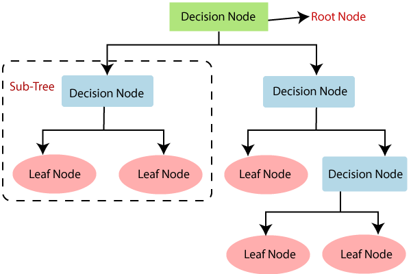

https://www.javatpoint.com/machine-learning-decision-tree-classification-algorithm

## for more details understanding of Decision Tress refer the the above link

```python
## now lests check for outliers
x.head()
```

|  | Age | Fare | B | C | D | E | F | G | T | o | male | Embarked_Q | Embarked_S |
| --- | --- | --- | --- | --- | --- | --- | --- | --- | --- | --- | --- | --- | --- |
| 0 | 22.0 | 7.2500 | 0 | 0 | 0 | 0 | 0 | 0 | 0 | 1 | 1 | 0 | 1 |
| 1 | 38.0 | 71.2833 | 0 | 1 | 0 | 0 | 0 | 0 | 0 | 0 | 0 | 0 | 0 |
| 2 | 26.0 | 7.9250 | 0 | 0 | 0 | 0 | 0 | 0 | 0 | 1 | 0 | 0 | 1 |
| 3 | 35.0 | 53.1000 | 0 | 1 | 0 | 0 | 0 | 0 | 0 | 0 | 0 | 0 | 1 |
| 4 | 35.0 | 8.0500 | 0 | 0 | 0 | 0 | 0 | 0 | 0 | 1 | 1 | 0 | 1 |

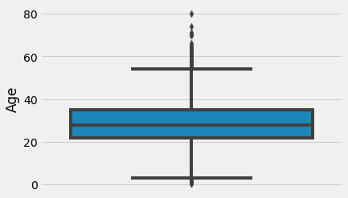

```python
sn.boxplot( x=None,
    y="Age",
    hue=None,
    data=x,
    order=None,
    hue_order=None,
    orient=None,
    color=None,
    palette=None,
    saturation=0.75,
    width=0.8,
    dodge=True,
    fliersize=5,
    linewidth=None,
    whis=1.5,
    ax=None)
```

```python
x[x["Age"]>60].shape
```

```
(22, 13)
```

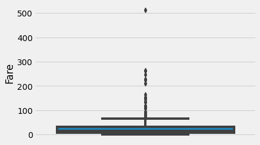

```python
sn.boxplot( x=None,
    y="Fare",
    hue=None,
    data=x,
    order=None,
    hue_order=None,
    orient=None,
    color=None,
    palette=None,
    saturation=0.75,
    width=0.8,
    dodge=True,
    fliersize=5,
    linewidth=None,
    whis=1.5,
    ax=None)
```

```python
x[x["Fare"]>100].shape
```

```
(53, 13)
```

```python
# now lets split our data into training into testing sets
from sklearn.model_selection import train_test_split
x_train,x_test,y_train,y_test = train_test_split(x,y,test_size=0.25,random_state=10)
```

```python
print(x_train.shape)
print(x_test.shape)
print(y_train.shape)
print(y_test.shape)
```

```
(668, 13)
(223, 13)
(668,)
(223,)
```

```python
from sklearn.tree import DecisionTreeClassifier
model = DecisionTreeClassifier()
model.fit(x_train,y_train)
```

```
DecisionTreeClassifier()
```

```python
train_predict = model.predict(x_train)
print("the score on training dataset is {}".format(model.score(x_train,y_train)))
```

```
the score on training dataset is 0.9820359281437125
```

```python
test_predict = model.predict(x_test)
print("the score on training dataset is {}".format(model.score(x_test,y_test)))
```

[output not shown]